# Batch effects, technical variables, and unwanted variation

Paulina Duda

#### Dependencies

```r
library("jackstraw")
library("SeuratData")
library("edge")
library("genefilter")
library("GEOquery")
library("sva")
library("Seurat")
library("tidyverse")
library("devtools")
library("patchwork")
library("RColorBrewer")
library("gplots")
library("data.table")
library("broom")
library("Biobase")
library("limma")
library("limma")
library("qvalue")
library("irlba")
library("Rtsne")
library("corpcor")
library("bladderbatch")
```

#### Load the `ExpressionSet` data

Make sure to apply log2 transformation and remove genes whose expression levels are below a threshold, 10:

```r
con = url("http://bowtie-bio.sourceforge.net/recount/ExpressionSets/bottomly_eset.RData")
load(file=con)
close(con)
edata <- as.matrix(exprs(bottomly.eset))
dim(edata)
```

```
[1] 36536    21
```

```r
edata[1:5,1:5]
```

```
                   SRX033480 SRX033488 SRX033481 SRX033489 SRX033482
ENSMUSG00000000001       369       744       287       769       348
ENSMUSG00000000003         0         0         0         0         0
ENSMUSG00000000028         0         1         0         1         1
ENSMUSG00000000031         0         0         0         0         0
ENSMUSG00000000037         0         1         1         5         0
```

```r
edata <- edata[rowMeans(edata) > 10, ]
edata <- log2(as.matrix(edata) + 1)
```

#### Bladder Cancer Gene Expression

```r
data(bladderdata)
pheno = pData(bladderEset)
edata = exprs(bladderEset)
dim(pheno)
```

```
[1] 57  4
```

```r
dim(edata)
```

```
[1] 22283    57
```

```r
edata[1:5,1:10]
```

```
          GSM71019.CEL GSM71020.CEL GSM71021.CEL GSM71022.CEL GSM71023.CEL
1007_s_at    10.115170     8.628044     8.779235     9.248569    10.256841
1053_at       5.345168     5.063598     5.113116     5.179410     5.181383
117_at        6.348024     6.663625     6.465892     6.116422     5.980457
121_at        8.901739     9.439977     9.540738     9.254368     8.798086
1255_g_at     3.967672     4.466027     4.144885     4.189338     4.078509
          GSM71024.CEL GSM71025.CEL GSM71026.CEL GSM71028.CEL GSM71029.CEL
1007_s_at    10.023133     9.108034     8.735616     9.803271    10.168602
1053_at       5.248418     5.252312     5.220931     5.595771     5.025180
117_at        5.796155     6.414849     6.846798     5.841478     6.352257
121_at        8.002870     9.093704     9.263386     7.789240     9.834564
1255_g_at     3.919740     4.402590     4.173666     3.590649     4.338196
```

```r
head(pheno)
```

|  | sample | outcome | batch | cancer |
| --- | --- | --- | --- | --- |
| GSM71019.CEL | 1 | Normal | 3 | Normal |
| GSM71020.CEL | 2 | Normal | 2 | Normal |
| GSM71021.CEL | 3 | Normal | 2 | Normal |
| GSM71022.CEL | 4 | Normal | 3 | Normal |
| GSM71023.CEL | 5 | Normal | 3 | Normal |
| GSM71024.CEL | 6 | Normal | 3 | Normal |

#### Using ComBat to clean a dataset

```
Found5batches
```

```
Adjusting for0covariate(s) or covariate level(s)
```

```
Standardizing Data across genes
```

```
Fitting L/S model and finding priors
```

```
Finding parametric adjustments
```

```
Adjusting the Data
```

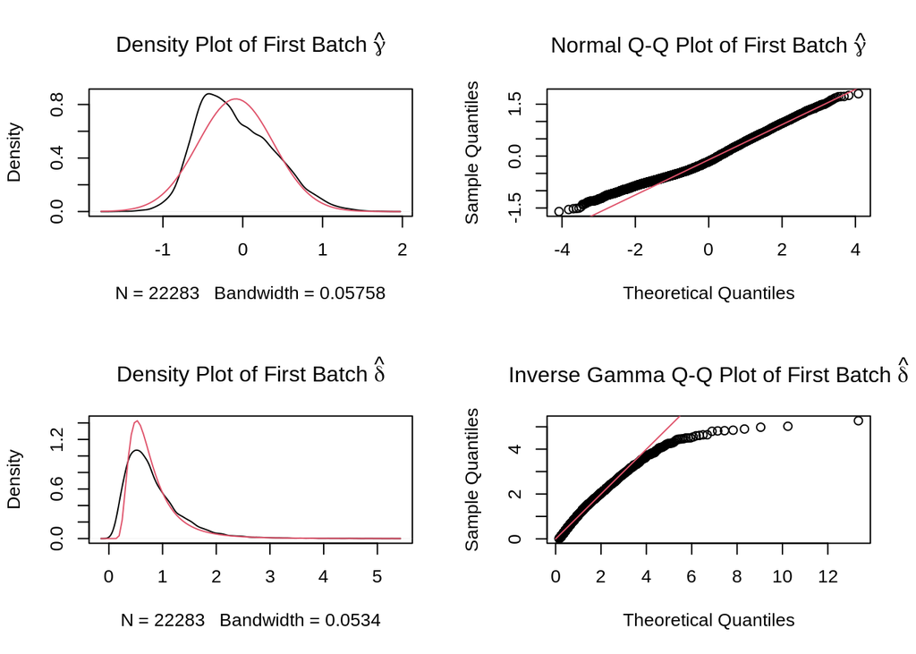

```r
batch = pheno$batch
combat_edata = ComBat(dat=edata, batch=pheno$batch, mod=model.matrix(~1, data=pheno), par.prior=TRUE, prior.plots=TRUE)
```

```r
dim(combat_edata)
```

```
[1] 22283    57
```

```r
combat_edata[1:10,1:10]
```

```
          GSM71019.CEL GSM71020.CEL GSM71021.CEL GSM71022.CEL GSM71023.CEL
1007_s_at    10.086492     8.593022     8.735540     8.904952    10.279650
1053_at       5.519207     5.113332     5.158352     5.262212     5.265272
117_at        6.561742     6.432693     6.270198     6.220636     6.020385
121_at        8.789976     9.223917     9.316884     9.194757     8.670993
1255_g_at     3.899327     4.403982     4.092681     4.221116     4.060228
1294_at       7.776518     7.019255     7.158185     6.861674     7.922848
1316_at       5.649287     5.970764     5.735524     5.654296     5.419312
1320_at       4.804678     4.950997     4.934006     5.054113     4.781219
1405_i_at     4.610682     5.134118     5.253532     4.949743     5.716855
1431_at       3.611859     3.838791     4.032779     3.929806     3.671820
          GSM71024.CEL GSM71025.CEL GSM71026.CEL GSM71028.CEL GSM71029.CEL
1007_s_at     9.961007     9.045478     8.694423     9.899764    10.045210
1053_at       5.369203     5.284904     5.256374     5.510407     5.078403
117_at        5.748943     6.228251     6.583223     5.959972     6.176814
121_at        7.758169     8.904430     9.060986     8.070843     9.587981
1255_g_at     3.829743     4.342488     4.120581     3.705901     4.280068
1294_at       7.981092     7.380569     7.191838     7.400875     7.738220
1316_at       4.974144     5.673047     6.034643     5.157916     5.495244
1320_at       4.565801     5.050053     4.983497     4.667655     4.648609
1405_i_at     5.670019     5.446926     4.823142     5.894279     4.899299
1431_at       3.630532     4.016920     4.053496     3.672131     3.910505
```

Evaluate if the cleaned data from ComBat has no relation to batch effects:

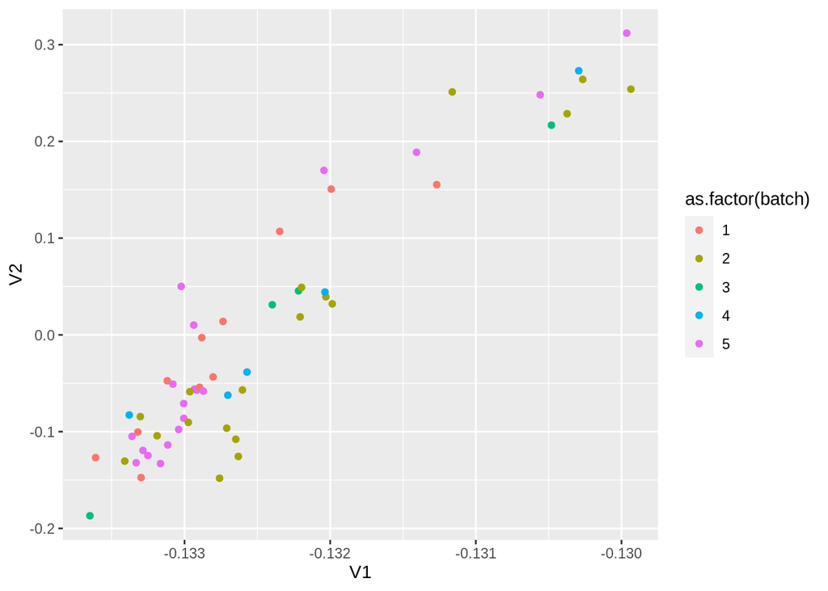

```r
svd.out.combat <- svd(combat_edata)
svd.combat.plot <- data.table(svd.out.combat$v[,1:10], pheno)

ggplot(svd.combat.plot) + geom_point(aes(x=V1, y=V2, col=as.factor(batch)))
```

> Homework Problem 2: Make heatmaps, BEFORE and AFTER cleaning the data using ComBat, where columns are arranged according to the study design. You must sort the columns such that 5 batches are shown. Cluster the rows, but do not cluster the columns (samples) when drawing a heatmap.

BEFORE:

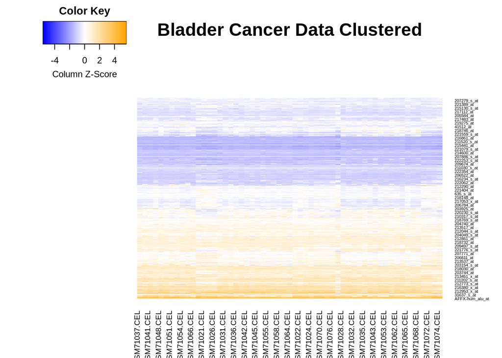

```r
my_palette <- colorRampPalette(c("blue", "white", "orange"))(n = 299)
# png("Duda_problem2.1.png",height=700,width=700)
heatmap.2(edata[,order(pheno$batch)],
          main = "Bladder Cancer Data Clustered", # heat map title
          notecol="black",      # change font color of cell labels to black
          density.info="none",  # turns off density plot inside color legend
          trace="none",         # turns off trace lines inside the heat map
          col=my_palette,       # use on color palette defined earlier
          dendrogram="none",     # only draw a row dendrogram
          scale="col",
          Rowv = TRUE,
          Colv = FALSE)
```

```r
# dev.off()
```

AFTER:

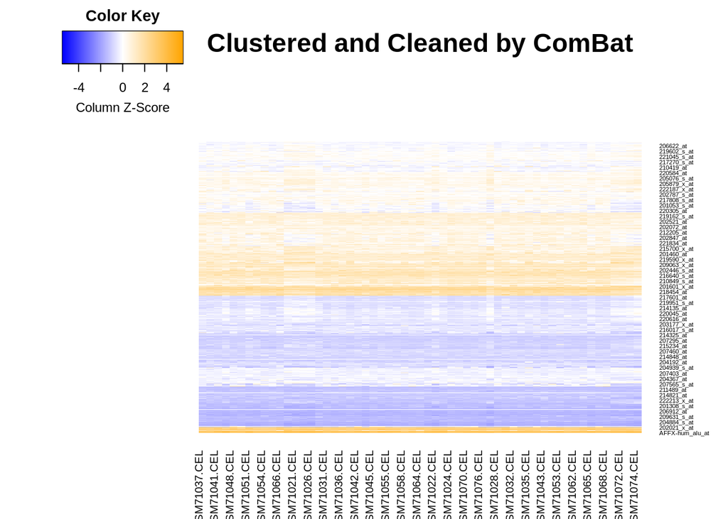

```r
# png("Duda_problem2.2.png",height=700,width=700)
heatmap.2(combat_edata[,order(pheno$batch)],
          main = "Clustered and Cleaned by ComBat", # heat map title
          notecol="black",      # change font color of cell labels to black
          density.info="none",  # turns off density plot inside color legend
          trace="none",         # turns off trace lines inside the heat map
          col=my_palette,       # use on color palette defined earlier
          dendrogram="none",     # only draw a row dendrogram
          scale="col",
          Rowv = TRUE,
          Colv = FALSE)
```

```r
# dev.off()
```

> Homework Problem 3: Make heatmaps of Pearson correlations statistics of samples. First, compute the correlation statistics among columns. Second, create a heatmap using heatmap.2(). Make sure to create or add labels for samples (cancer vs. normal; batch numbers; others).

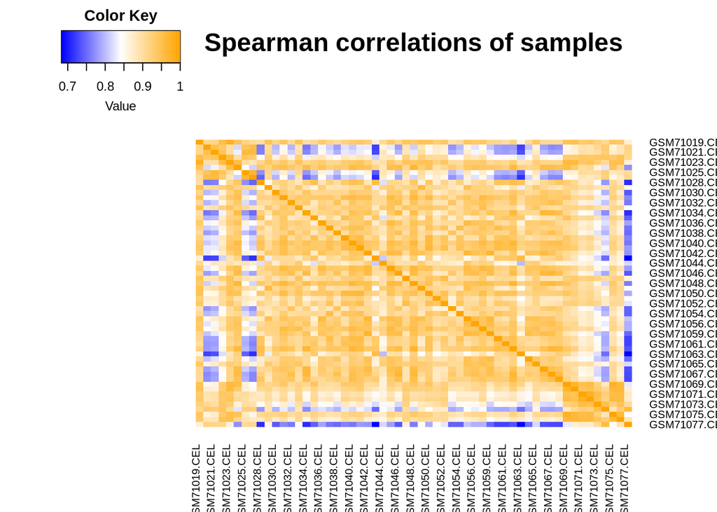

```r
# png("Duda_problem3.png",height=700,width=700)
heatmap.2(cor(edata, method = "spearman"),
          main = "Spearman correlations of samples", # heat map title
          notecol="black",      # change font color of cell labels to black
          density.info="none",  # turns off density plot inside color legend
          trace="none",         # turns off trace lines inside the heat map
          col=my_palette,       # use on color palette defined earlier
          dendrogram="none",    # only draw a row dendrogram
          scale="none",
          Rowv = FALSE,
          Colv = FALSE)
```

```r
# dev.off()
```

> Homework Problem 4: Apply two different Linear Models to the Bottomly et al. data. First, using a conventional approach, create a linear model with a genetic strain (biological variable) and an experimental number (technical variable) on uncorrected gene expression data. Second, create a linear model with a genetic strain (biological variables) on corrected gene expression data from ComBat. Make a scatter plots of coefficients and a histogram of p-values as done in this notebook. Make sure that you are pulling out the correct coefficients, not any or all coefficients.

Unorrected gene expression data

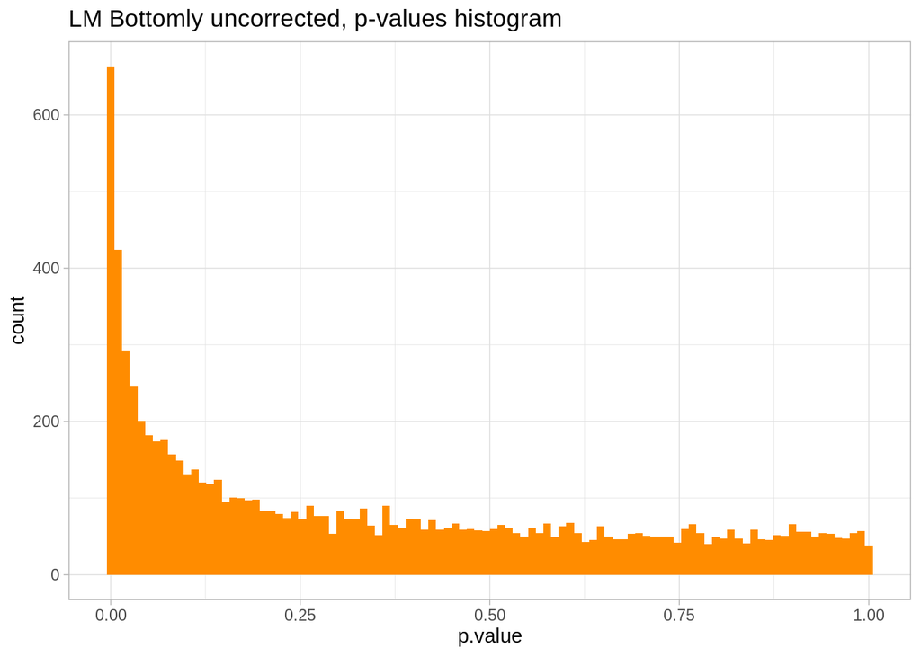

```r
pheno = pData(bottomly.eset)
edata = exprs(bottomly.eset)
edata <- edata[rowMeans(edata) > 10, ]
edata <- log2(as.matrix(edata) + 1)

mod = lm(t(edata) ~ as.factor(pheno$strain) + as.factor(pheno$experiment.number))
mod_tidy <- tidy(mod)
ggplot(mod_tidy %>% filter(term == 'as.factor(pheno$strain)DBA/2J')) +
    geom_histogram(aes(x=p.value), bins = 100, fill="darkorange") +
    ggtitle('LM Bottomly uncorrected, p-values histogram') +
    theme_light()
```

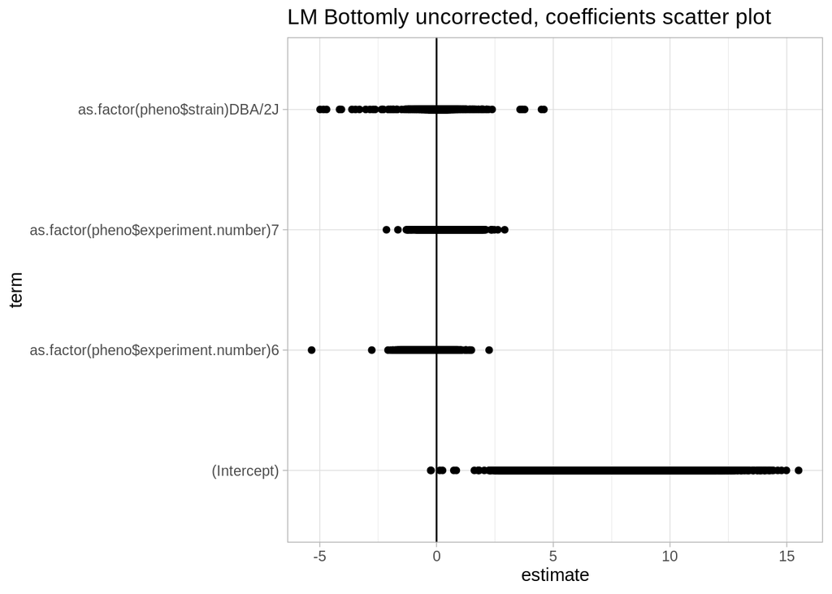

```r
ggsave('duda_problem4.1.pdf')

ggplot(mod_tidy, aes(estimate, term)) +
     geom_point() +
     geom_vline(xintercept = 0) + ggtitle('LM Bottomly uncorrected, coefficients scatter plot') +
     theme_light()
```

```r
ggsave('duda_problem4.2.pdf')
```

Corrected gene expression data from ComBat

```
Found3batches
```

```
Adjusting for0covariate(s) or covariate level(s)
```

```
Standardizing Data across genes
```

```
Fitting L/S model and finding priors
```

```
Finding parametric adjustments
```

```
Adjusting the Data
```

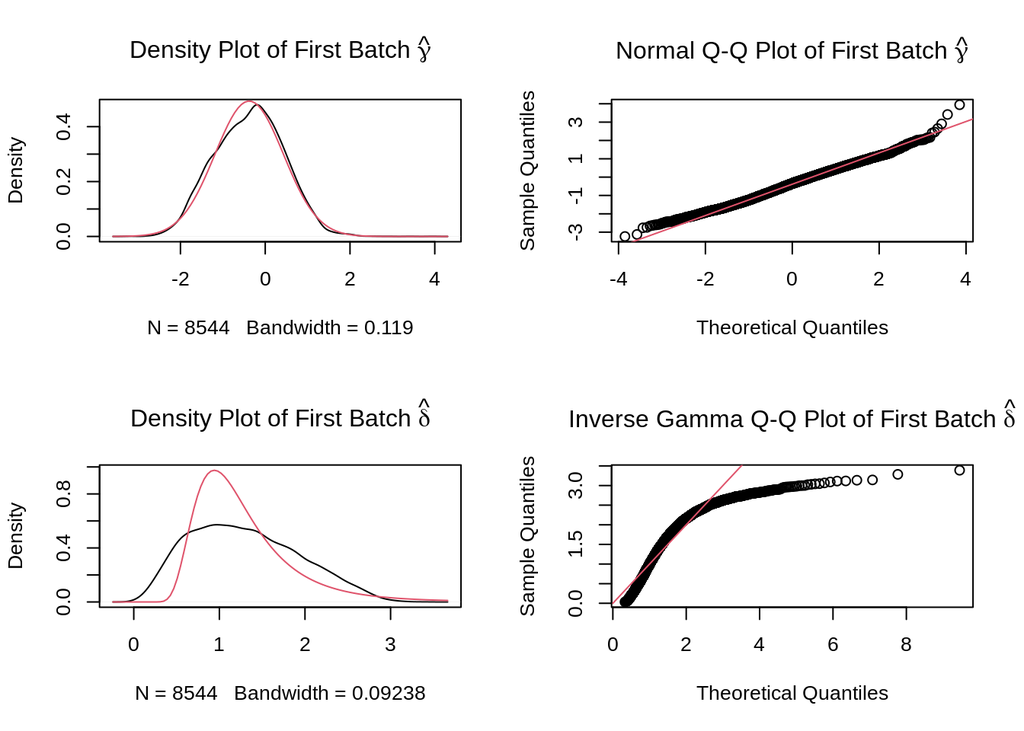

```r
combat_edata = ComBat(dat=edata, batch=pheno$experiment.number,
               mod=model.matrix(~1, data=pheno), par.prior=TRUE, prior.plots=TRUE)
```

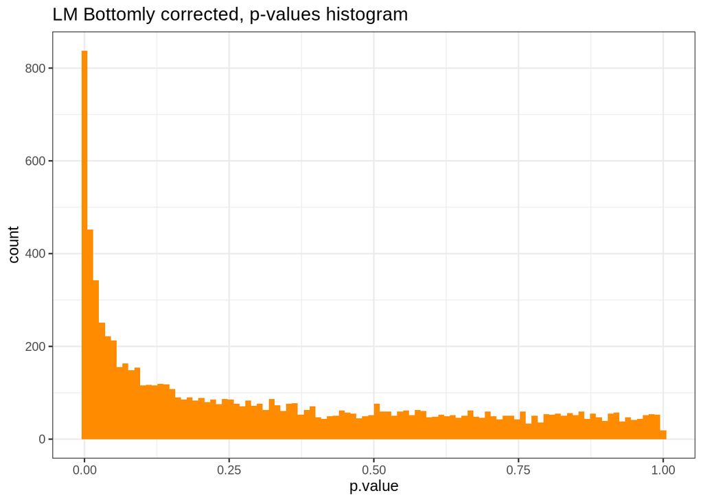

```r
modcombat = lm(t(combat_edata) ~ as.factor(pheno$strain))
modcombat_tidy <- tidy(modcombat)
ggplot(modcombat_tidy %>% filter(term == 'as.factor(pheno$strain)DBA/2J')) +
    geom_histogram(aes(x=p.value), bins = 100, fill="darkorange") +
    ggtitle('LM Bottomly corrected, p-values histogram') +
    theme_bw()
```

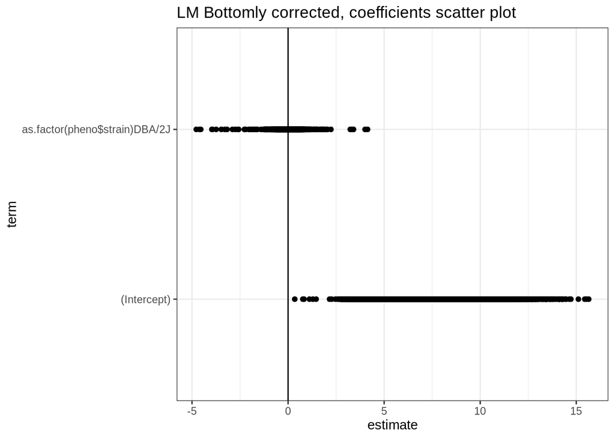

```r
ggsave('duda_problem4.3.pdf')

ggplot(modcombat_tidy, aes(estimate, term)) +
     geom_point() +
     geom_vline(xintercept = 0) +
     ggtitle('LM Bottomly corrected, coefficients scatter plot') +
     theme_bw()
```

```r
ggsave('duda_problem4.4.pdf')
```

[figure not shown]

```r
est_compare <- tibble(
  LinearModel = mod_tidy %>% filter(term == "as.factor(pheno$strain)DBA/2J") %>% select("p.value") %>% unlist,
  ComBat = modcombat_tidy %>% filter(term == "as.factor(pheno$strain)DBA/2J") %>% select("p.value") %>% unlist)

ggplot(est_compare, aes(x=LinearModel, y=ComBat)) +
     geom_point(col="darkgrey", alpha=.5, size=.5) +
     geom_abline(intercept=0, slope=1, col="darkred") +
     geom_smooth(method = "lm", se = TRUE) +
     ggtitle('LM coefficienties filtered vs unfiltered') +
     theme_bw()
```

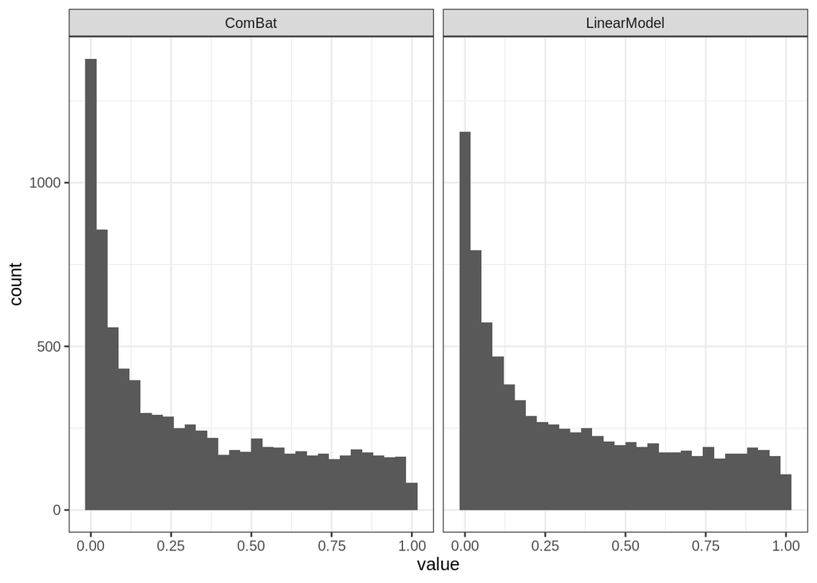

```r
ggsave('duda_problem4.5.pdf')

pvalues <- tibble(
  LinearModel = mod_tidy %>% filter(term == "as.factor(pheno$strain)DBA/2J") %>% select("p.value") %>% unlist,
  ComBat = modcombat_tidy %>% filter(term == "as.factor(pheno$strain)DBA/2J") %>% select("p.value") %>% unlist)

pvalues_gather = gather(pvalues)
ggplot(pvalues_gather, aes(x=value)) +
    geom_histogram() +
    facet_wrap(~key) +
    theme_bw()
```

```r
ggsave('duda_problem4.6.pdf')
```

> Homework Problem 5: Apply ComBat and SVA to the Bottomly et al. data. Make a scatter plots of coefficients and a histogram of p-values, comparing results based on ComBat and SVA. Assume that the biological variables in Bottomly et al data is the genetic strains. Make sure that you are pulling out the correct coefficients/pvalues, not any or all of them.

Combat

```
Found3batches
```

```
Adjusting for0covariate(s) or covariate level(s)
```

```
Standardizing Data across genes
```

```
Fitting L/S model and finding priors
```

```
Finding parametric adjustments
```

```
Adjusting the Data
```

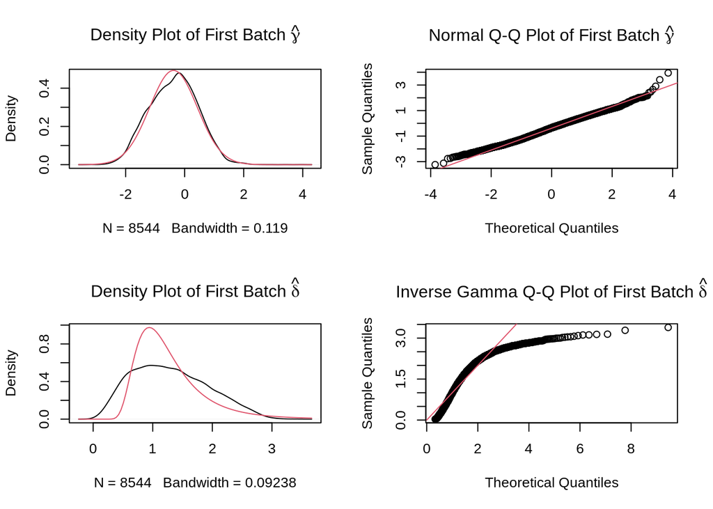

```r
combat_edata = ComBat(dat=edata, batch=pheno$experiment.number,
               mod=model.matrix(~1, data=pheno), par.prior=TRUE, prior.plots=TRUE)
```

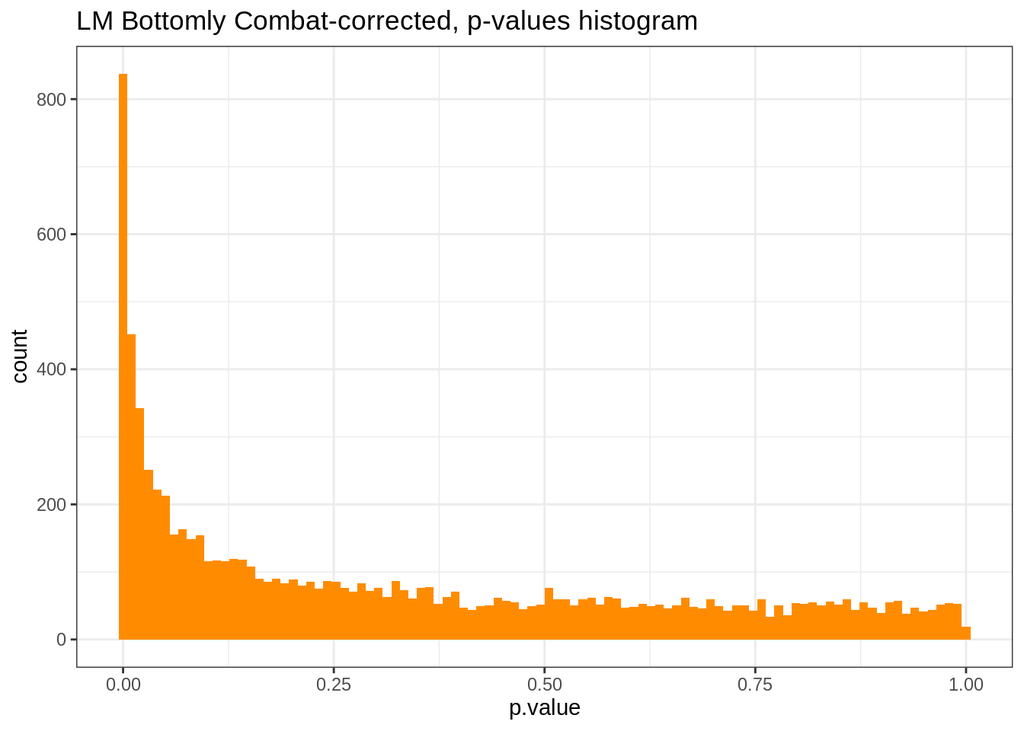

```r
modcombat = lm(t(combat_edata) ~ as.factor(pheno$strain))
modcombat_tidy <- tidy(modcombat)
ggplot(modcombat_tidy %>% filter(term == 'as.factor(pheno$strain)DBA/2J')) +
    geom_histogram(aes(x=p.value), bins = 100, fill="darkorange") +
    ggtitle('LM Bottomly Combat-corrected, p-values histogram') +
    theme_bw()
```

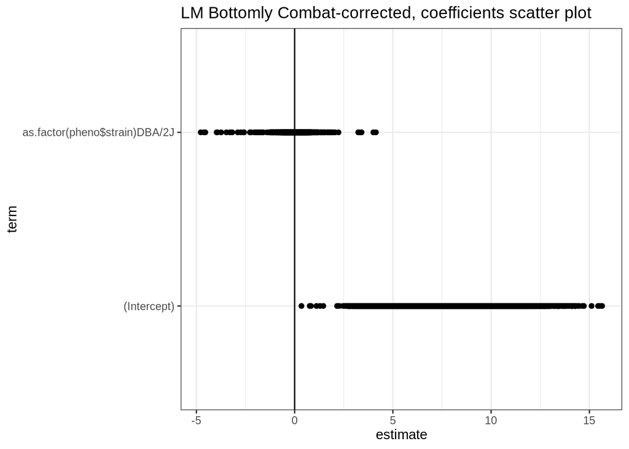

```r
ggsave('duda_problem5.1.pdf')

ggplot(modcombat_tidy, aes(estimate, term)) +
     geom_point() +
     geom_vline(xintercept = 0) +
     ggtitle('LM Bottomly Combat-corrected, coefficients scatter plot') +
     theme_bw()
```

```r
ggsave('duda_problem5.2.pdf')
```

SVA

```r
mod = model.matrix(~as.factor(strain), data=pheno)
mod0 = model.matrix(~1, data=pheno)
sva_output = sva(edata, mod, mod0, n.sv=num.sv(edata, mod, method="leek"))
```

```
Number of significant surrogate variables is:  2
Iteration (out of 5 ):1  2  3  4  5
```

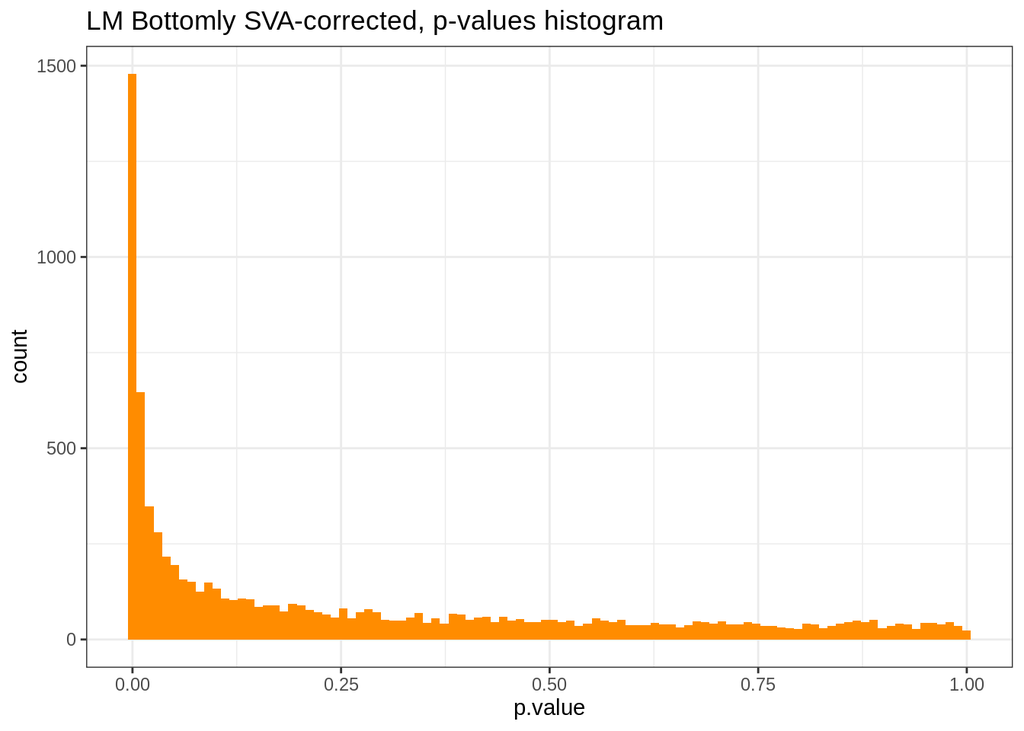

```r
modsva = lm(t(edata) ~ as.factor(pheno$strain) + sva_output$sv)
modsva_tidy <- tidy(modsva)
ggplot(modsva_tidy %>% filter(term == 'as.factor(pheno$strain)DBA/2J')) +
    geom_histogram(aes(x=p.value), bins = 100, fill="darkorange") +
    ggtitle('LM Bottomly SVA-corrected, p-values histogram') +
    theme_bw()
```

[figure not shown]

```r
ggsave('duda_problem5.3.pdf')

ggplot(modcombat_tidy, aes(estimate, term)) +
     geom_point() +
     geom_vline(xintercept = 0) +
     ggtitle('LM Bottomly SVA-corrected, coefficients scatter plot') +
     theme_bw()
```

```r
ggsave('duda_problem5.4.pdf')
```

Comparing

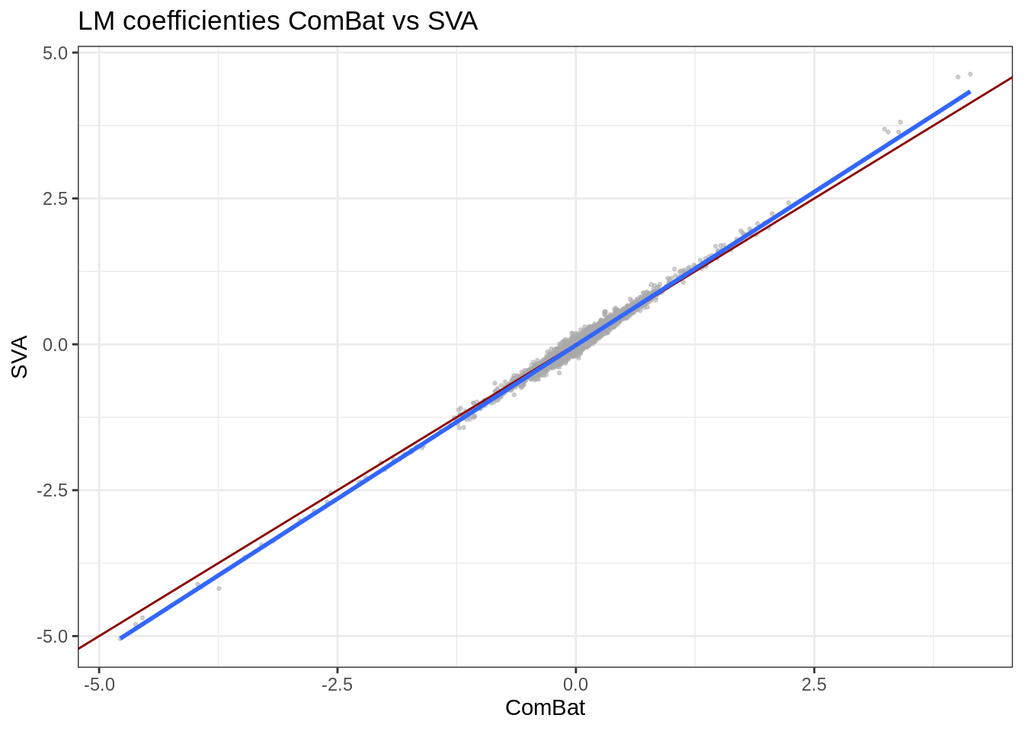

```r
compare <- tibble(
  ComBat = modcombat_tidy %>% filter(term == "as.factor(pheno$strain)DBA/2J") %>% select("estimate") %>% unlist,
  SVA = modsva_tidy %>% filter(term == "as.factor(pheno$strain)DBA/2J") %>% select("estimate") %>% unlist)
pvalues <- tibble(
  ComBat = modcombat_tidy %>% filter(term == "as.factor(pheno$strain)DBA/2J") %>% select("p.value") %>% unlist,
  SVA = modsva_tidy %>% filter(term == "as.factor(pheno$strain)DBA/2J") %>% select("p.value") %>% unlist)

ggplot(compare, aes(x=ComBat, y=SVA)) +
     geom_point(col="darkgrey", alpha=.5, size=.5) +
     geom_abline(intercept=0, slope=1, col="darkred") +
     geom_smooth(method = "lm", se = TRUE) +
     ggtitle('LM coefficienties ComBat vs SVA') +
     theme_bw()
```

```r
ggsave('duda_problem5.5.pdf')
```

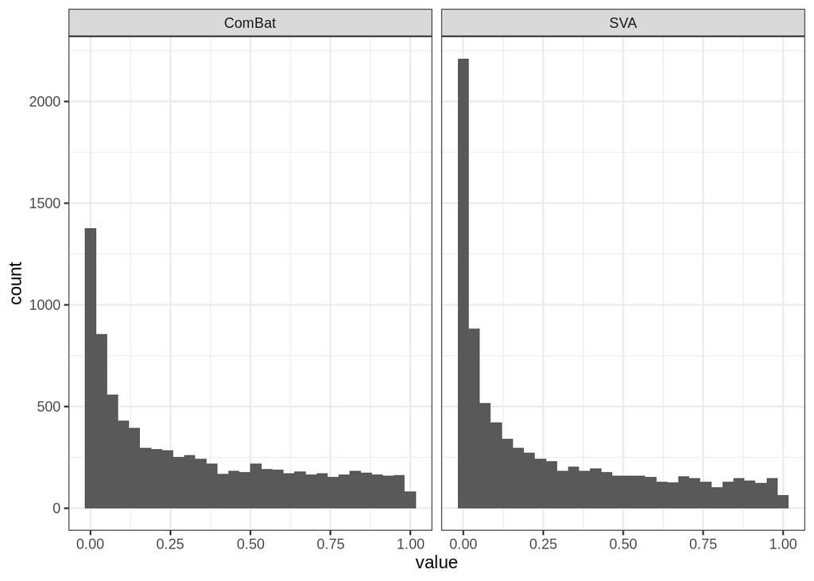

```r
pvalues_gather = gather(pvalues)

ggplot(pvalues_gather, aes(x=value)) +
    geom_histogram() +
    facet_wrap(~key) +
    theme_bw()
```

```r
ggsave('duda_problem5.6.pdf')
```